# Analysis of New Castle County property data by subdivision

### How does DOM compare to other factors?

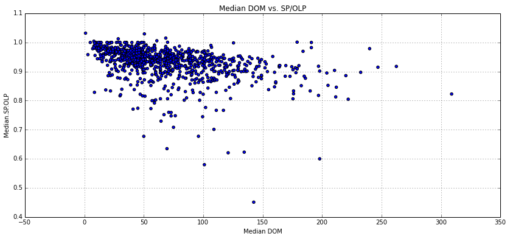

```python
df.plot(
    x="Median DOM",
    y="Median.SP.OLP",
    kind='scatter',
    title="Median DOM vs. SP/OLP",
    figsize=[14,6])
```

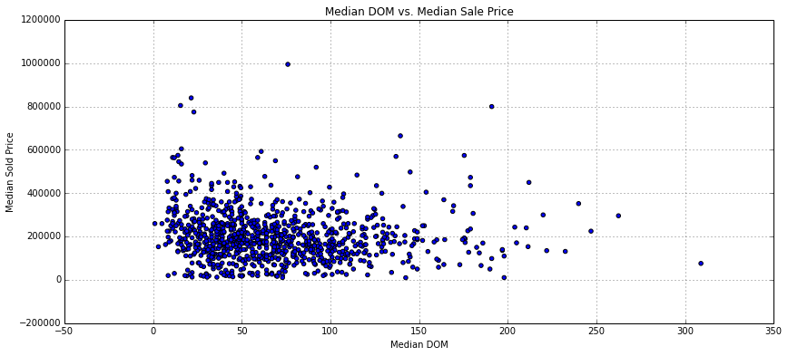

```python
df.plot(
    x="Median DOM",
    y="Median Sold Price",
    kind='scatter',
    title="Median DOM vs. Median Sale Price",
    figsize=[14,6])
```

```
Median DOM by year:
```

```
array([[<matplotlib.axes.AxesSubplot object at 0x115c90ad0>,
        <matplotlib.axes.AxesSubplot object at 0x114ff8390>]], dtype=object)
```

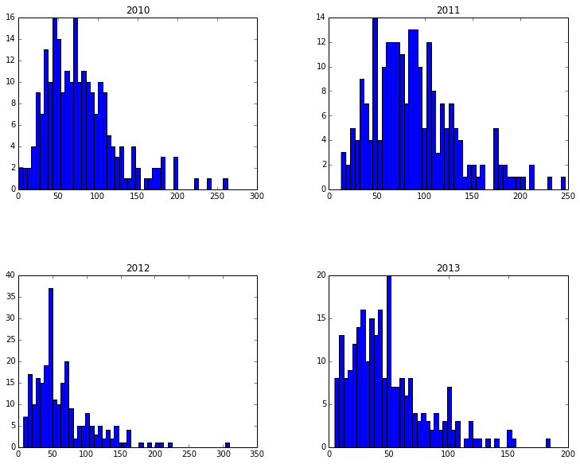

```python
print "Median DOM by year:"
df['Median DOM'].hist(by=df.Year, figsize=[12,10])
```

```
SP/OLP by year
```

```
array([[<matplotlib.axes.AxesSubplot object at 0x115008790>,
        <matplotlib.axes.AxesSubplot object at 0x1169ad4d0>]], dtype=object)
```

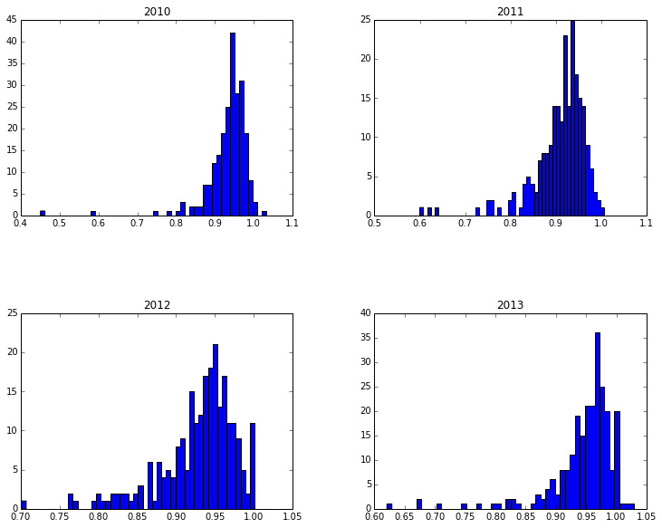

```python
print "SP/OLP by year"
df['Median.SP.OLP'].hist(by=df.Year, figsize=[12,10])
```

```
SP/OLP For All Years
```

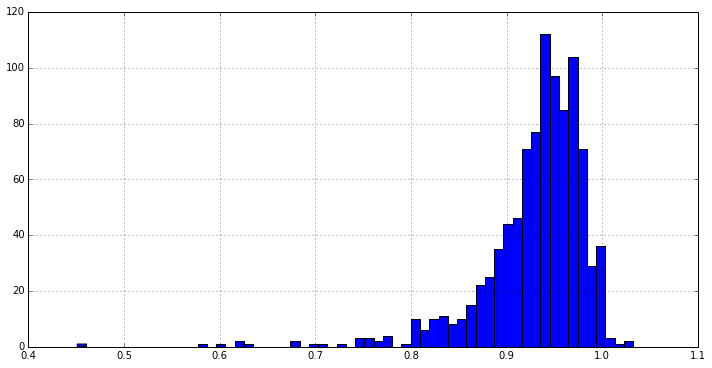

```python
print "SP/OLP For All Years"
df['Median.SP.OLP'].hist(bins=60, figsize=[12,6])
```

# 1. In which subdivisions are houses selling the fastest? Selling slowest?

Grouping our data by subdivision, we are able to run each through a linear regression with SciPy's `linregress` function.

Back to top

```python
def calculateSlope(df, attribute, r_squared_threshold=R2_THRESHOLD):
    """Gets the slope of an attribute of the dataframe along with
    min, max and r-squared values."""
    # Using scipy's linregress, get the slope of dom/year for each subdivision
    slope = pd.DataFrame(df.apply(lambda x: linregress(y=x[attribute], x=x.Year)[0]))
    r2 = pd.DataFrame(df.apply(lambda x: linregress(y=x[attribute], x=x.Year)[2]**2))
    output = pd.merge(left=slope, right=r2, left_index=True, right_index=True)

    # Get the max and min DOM for each subdivision.
    output = pd.merge(left=output, right=pd.DataFrame(df[attribute].min()), left_index=True, right_index=True)
    output = pd.merge(left=output, right=pd.DataFrame(df[attribute].max()), left_index=True, right_index=True)
    output= pd.merge(left=output, right=pd.DataFrame(df['Sales'].sum()), left_index=True, right_index=True)

    # Fix Column names
    attribute = re.sub(r'[\W]+', '_', attribute).lower()
    output.columns = [attribute+'_slope', attribute+'_r2', attribute+'_min', attribute+'_max', 'sales_count']

    return output, output[output[attribute+'_r2'] >= r_squared_threshold]
```

```
array([[<matplotlib.axes.AxesSubplot object at 0x1178dc190>,
        <matplotlib.axes.AxesSubplot object at 0x117a58410>]], dtype=object)
```

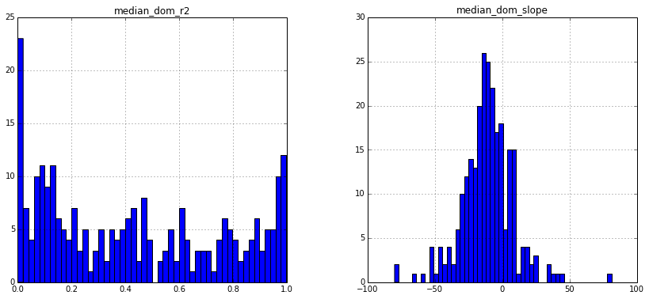

```python
median_dom, median_dom_adj = calculateSlope(by_subdivision, 'Median DOM')
median_dom[['median_dom_slope', 'median_dom_r2']].hist(bins=50, figsize=[14,6])
```

```python
print "The best fit:"
median_dom[median_dom.median_dom_r2 == median_dom.median_dom_r2.max()]
```

```
The best fit:
```

| Subdiv | median_dom_slope | median_dom_r2 | median_dom_min | median_dom_max | sales_count |
| --- | --- | --- | --- | --- | --- |
| Towne Ests | -11.5 | 0.997486 | 8.5 | 31.5 | 33 |

1 rows × 5 columns

```python
print "The Worst fit:"
median_dom[median_dom.median_dom_r2 == median_dom.median_dom_r2.min()]
```

```
The Worst fit:
```

| Subdiv | median_dom_slope | median_dom_r2 | median_dom_min | median_dom_max | sales_count |
| --- | --- | --- | --- | --- | --- |
| Ballymeade | -0.05 | 0.000008 | 13 | 67.5 | 31 |

1 rows × 5 columns

### The top and bottom five for DOM

```python
print "TOP 5:"
median_dom.sort(['median_dom_slope']).head(5)
```

```
TOP 5:
```

| Subdiv | median_dom_slope | median_dom_r2 | median_dom_min | median_dom_max | sales_count |
| --- | --- | --- | --- | --- | --- |
| Linden Knoll | -80.000000 | 0.930052 | 37.0 | 197.0 | 28 |
| Midtown Brandywine | -78.107143 | 0.796109 | 15.0 | 262.5 | 18 |
| Buena Vista Park | -65.285714 | 0.958357 | 34.0 | 222.0 | 23 |
| Red Lion Chase | -60.000000 | 0.995483 | 92.0 | 212.0 | 24 |
| Wilmington - Delaware Avenue Area (11) | -53.071429 | 0.821442 | 23.5 | 197.0 | 25 |

5 rows × 5 columns

```python
print "TOP 5 (adjusted for better R^2 values):"
median_dom_adj.sort(['median_dom_slope']).head(5)
```

```
TOP 5 (adjusted for better R^2 values):
```

| Subdiv | median_dom_slope | median_dom_r2 | median_dom_min | median_dom_max | sales_count |
| --- | --- | --- | --- | --- | --- |
| Linden Knoll | -80.000000 | 0.930052 | 37.0 | 197.0 | 28 |
| Midtown Brandywine | -78.107143 | 0.796109 | 15.0 | 262.5 | 18 |
| Buena Vista Park | -65.285714 | 0.958357 | 34.0 | 222.0 | 23 |
| Red Lion Chase | -60.000000 | 0.995483 | 92.0 | 212.0 | 24 |
| Wilmington - Delaware Avenue Area (11) | -53.071429 | 0.821442 | 23.5 | 197.0 | 25 |

5 rows × 5 columns

```python
print "Bottom 5:"
median_dom.sort(['median_dom_slope'], ascending=False).head(5)
```

```
Bottom 5:
```

| Subdiv | median_dom_slope | median_dom_r2 | median_dom_min | median_dom_max | sales_count |
| --- | --- | --- | --- | --- | --- |
| Windybush | 81.250000 | 0.995698 | 18 | 180.5 | 19 |
| North Hills | 44.500000 | 0.288642 | 45 | 210.5 | 16 |
| Lone Manor | 39.500000 | 0.869543 | 21 | 100.0 | 19 |
| Sedgely Farms | 39.250000 | 0.773860 | 61 | 139.5 | 18 |
| Christiana Village | 35.428571 | 0.107996 | 3 | 309.0 | 16 |

5 rows × 5 columns

```python
print "Bottom 5 (adjusted for better R^2 values):"
median_dom_adj.sort(['median_dom_slope'], ascending=False).head(5)
```

```
Bottom 5 (adjusted for better R^2 values):
```

| Subdiv | median_dom_slope | median_dom_r2 | median_dom_min | median_dom_max | sales_count |
| --- | --- | --- | --- | --- | --- |
| Windybush | 81.250000 | 0.995698 | 18 | 180.5 | 19 |
| Lone Manor | 39.500000 | 0.869543 | 21 | 100.0 | 19 |
| Sedgely Farms | 39.250000 | 0.773860 | 61 | 139.5 | 18 |
| Washington Park | 35.100000 | 0.706529 | 33 | 135.0 | 30 |
| Clearfield | 25.142857 | 0.741478 | 101 | 185.0 | 21 |

5 rows × 5 columns

### Close look at top and bottom DOM subdivisions

#### The top subdivisions (both normal and R^2 corrected)

```python
df[df.index == median_dom[median_dom.median_dom_slope == median_dom.median_dom_slope.min()].index]
```

| Subdiv | Year | Sales | Median Sold Price | Avg.SP | Median DOM | Avg.DOM | Median.SP.OLP | Median.SP.LP |
| --- | --- | --- | --- | --- | --- | --- | --- | --- |
| Linden Knoll | 2010 | 7 | 136000 | 145178.5714 | 197 | 205.285714 | 0.817936 | 0.941176 |
| Linden Knoll | 2011 | 10 | 126500 | 125850.0000 | 79 | 132.800000 | 0.929530 | 0.954692 |
| Linden Knoll | 2012 | 11 | 117000 | 118818.1818 | 37 | 92.181818 | 0.925926 | 0.955414 |

3 rows × 8 columns

```python
df[df.index == median_dom[median_dom.median_dom_slope == median_dom_adj.median_dom_slope.min()].index]
```

| Subdiv | Year | Sales | Median Sold Price | Avg.SP | Median DOM | Avg.DOM | Median.SP.OLP | Median.SP.LP |
| --- | --- | --- | --- | --- | --- | --- | --- | --- |
| Linden Knoll | 2010 | 7 | 136000 | 145178.5714 | 197 | 205.285714 | 0.817936 | 0.941176 |
| Linden Knoll | 2011 | 10 | 126500 | 125850.0000 | 79 | 132.800000 | 0.929530 | 0.954692 |
| Linden Knoll | 2012 | 11 | 117000 | 118818.1818 | 37 | 92.181818 | 0.925926 | 0.955414 |

3 rows × 8 columns

#### The bottom subdivisions (both normal and R^2 corrected)

```python
df[df.index == median_dom[median_dom.median_dom_slope == median_dom.median_dom_slope.max()].index]
```

| Subdiv | Year | Sales | Median Sold Price | Avg.SP | Median DOM | Avg.DOM | Median.SP.OLP | Median.SP.LP |
| --- | --- | --- | --- | --- | --- | --- | --- | --- |
| Windybush | 2010 | 6 | 293000 | 299500.0000 | 18.0 | 66.833333 | 0.965648 | 0.977710 |
| Windybush | 2011 | 7 | 255000 | 278500.0000 | 90.0 | 123.714286 | 0.966667 | 0.966667 |
| Windybush | 2012 | 6 | 307000 | 317333.3333 | 180.5 | 151.666667 | 0.920330 | 0.954299 |

3 rows × 8 columns

```python
df[df.index == median_dom[median_dom.median_dom_slope == median_dom_adj.median_dom_slope.max()].index]
```

| Subdiv | Year | Sales | Median Sold Price | Avg.SP | Median DOM | Avg.DOM | Median.SP.OLP | Median.SP.LP |
| --- | --- | --- | --- | --- | --- | --- | --- | --- |
| Windybush | 2010 | 6 | 293000 | 299500.0000 | 18.0 | 66.833333 | 0.965648 | 0.977710 |
| Windybush | 2011 | 7 | 255000 | 278500.0000 | 90.0 | 123.714286 | 0.966667 | 0.966667 |
| Windybush | 2012 | 6 | 307000 | 317333.3333 | 180.5 | 151.666667 | 0.920330 | 0.954299 |

3 rows × 8 columns

# 2. In which subdivisions is the median sale price improving most? Dropping most?

Back to top

```
array([[<matplotlib.axes.AxesSubplot object at 0x117a5eb90>,
        <matplotlib.axes.AxesSubplot object at 0x117c84d90>]], dtype=object)
```

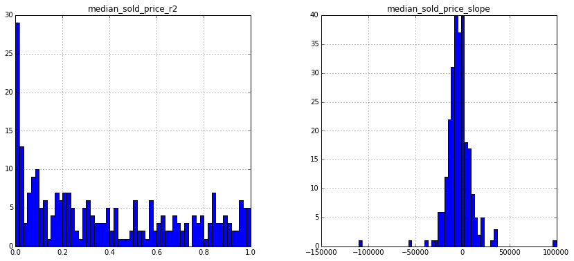

```python
median_saleprice, median_saleprice_adj = calculateSlope(by_subdivision, 'Median Sold Price')

median_saleprice[['median_sold_price_r2', 'median_sold_price_slope']].hist(bins=60, figsize=[14,6])
```

```python
print "The best fit:"
median_saleprice[median_saleprice.median_sold_price_r2 == median_saleprice.median_sold_price_r2.max()]
```

```
The best fit:
```

| Subdiv | median_sold_price_slope | median_sold_price_r2 | median_sold_price_min | median_sold_price_max | sales_count |
| --- | --- | --- | --- | --- | --- |
| Linden Knoll | -9500 | 1 | 117000 | 136000 | 28 |

1 rows × 5 columns

```python
print "The Worst fit:"
median_saleprice[median_saleprice.median_sold_price_r2 == median_saleprice.median_sold_price_r2.min()]
```

```
The Worst fit:
```

| Subdiv | median_sold_price_slope | median_sold_price_r2 | median_sold_price_min | median_sold_price_max | sales_count |
| --- | --- | --- | --- | --- | --- |
| Holloway Terrace | 97.5 | 0.00004 | 64475 | 110000 | 49 |

1 rows × 5 columns

### The top and bottom 5 for median saleprice

```python
print "TOP 5:"
median_saleprice.sort(['median_sold_price_slope'], ascending=False).head(5)
```

```
TOP 5:
```

| Subdiv | median_sold_price_slope | median_sold_price_r2 | median_sold_price_min | median_sold_price_max | sales_count |
| --- | --- | --- | --- | --- | --- |
| Westover Hills | 99650.000000 | 0.898651 | 574500 | 840000 | 53 |
| Wilmington - Delaware Avenue Area (11) | 36303.571429 | 0.488195 | 69000 | 227450 | 25 |
| Sedgely Farms | 36000.000000 | 0.527616 | 569950 | 664950 | 18 |
| Red Lion Chase | 35000.000000 | 0.956035 | 450000 | 520000 | 24 |
| Deerhurst | 32700.000000 | 0.727557 | 255000 | 360000 | 35 |

5 rows × 5 columns

```python
print "TOP 5 (adjusted for R-squared)"
median_saleprice_adj.sort(['median_sold_price_slope'], ascending=False).head(5)
```

```
TOP 5 (adjusted for R-squared)
```

| Subdiv | median_sold_price_slope | median_sold_price_r2 | median_sold_price_min | median_sold_price_max | sales_count |
| --- | --- | --- | --- | --- | --- |
| Westover Hills | 99650 | 0.898651 | 574500 | 840000 | 53 |
| Sedgely Farms | 36000 | 0.527616 | 569950 | 664950 | 18 |
| Red Lion Chase | 35000 | 0.956035 | 450000 | 520000 | 24 |
| Deerhurst | 32700 | 0.727557 | 255000 | 360000 | 35 |
| Newark | 22625 | 0.871836 | 182250 | 227500 | 28 |

5 rows × 5 columns

```python
print "BOTTOM 5:"
median_saleprice.sort(['median_sold_price_slope']).head(5)
```

```
BOTTOM 5:
```

| Subdiv | median_sold_price_slope | median_sold_price_r2 | median_sold_price_min | median_sold_price_max | sales_count |
| --- | --- | --- | --- | --- | --- |
| The Pointe | -110000.000000 | 0.834003 | 775000 | 995000 | 23 |
| Wawaset Park | -56750.000000 | 0.882233 | 379000 | 492500 | 27 |
| North Hills | -37850.000000 | 0.837053 | 173300 | 249000 | 16 |
| Crossland at Canal | -30537.300000 | 0.218478 | 290000 | 473124 | 49 |
| Brandywine Hills | -27678.571429 | 0.377159 | 297500 | 435000 | 34 |

5 rows × 5 columns

```python
print "BOTTOM 5 (adjusted for better R-squared):"
median_saleprice_adj.sort(['median_sold_price_slope']).head(5)
```

```
BOTTOM 5 (adjusted for better R-squared):
```

| Subdiv | median_sold_price_slope | median_sold_price_r2 | median_sold_price_min | median_sold_price_max | sales_count |
| --- | --- | --- | --- | --- | --- |
| The Pointe | -110000.000000 | 0.834003 | 775000 | 995000 | 23 |
| Wawaset Park | -56750.000000 | 0.882233 | 379000 | 492500 | 27 |
| North Hills | -37850.000000 | 0.837053 | 173300 | 249000 | 16 |
| Christiana Village | -24157.142857 | 0.790897 | 76000 | 153000 | 16 |
| Roselle | -23878.571429 | 0.858990 | 134900 | 205000 | 28 |

5 rows × 5 columns

### Close look at the top and bottom subdivisions by change in median saleprice

#### The top subdivisions (both normal and R2 adjusted)

```python
df[df.index == median_saleprice[median_saleprice.median_sold_price_slope == median_saleprice.median_sold_price_slope.max()].index]
```

| Subdiv | Year | Sales | Median Sold Price | Avg.SP | Median DOM | Avg.DOM | Median.SP.OLP | Median.SP.LP |
| --- | --- | --- | --- | --- | --- | --- | --- | --- |
| Westover Hills | 2010 | 10 | 574500 | 746500.0000 | 175.5 | 210.000000 | 0.906335 | 0.956193 |
| Westover Hills | 2011 | 11 | 605000 | 676677.2727 | 16.0 | 52.909091 | 0.954545 | 0.959184 |
| Westover Hills | 2012 | 20 | 805000 | 880490.0000 | 15.5 | 124.450000 | 0.979941 | 0.979941 |
| Westover Hills | 2013 | 12 | 840000 | 861500.0000 | 21.5 | 102.166667 | 0.934021 | 0.961632 |

4 rows × 8 columns

```python
df[df.index == median_saleprice[median_saleprice.median_sold_price_slope == median_saleprice_adj.median_sold_price_slope.max()].index]
```

| Subdiv | Year | Sales | Median Sold Price | Avg.SP | Median DOM | Avg.DOM | Median.SP.OLP | Median.SP.LP |
| --- | --- | --- | --- | --- | --- | --- | --- | --- |
| Westover Hills | 2010 | 10 | 574500 | 746500.0000 | 175.5 | 210.000000 | 0.906335 | 0.956193 |
| Westover Hills | 2011 | 11 | 605000 | 676677.2727 | 16.0 | 52.909091 | 0.954545 | 0.959184 |
| Westover Hills | 2012 | 20 | 805000 | 880490.0000 | 15.5 | 124.450000 | 0.979941 | 0.979941 |
| Westover Hills | 2013 | 12 | 840000 | 861500.0000 | 21.5 | 102.166667 | 0.934021 | 0.961632 |

4 rows × 8 columns

#### The bottom subdivisions (both normal and r-squared adjusted)

```python
df[df.index == median_saleprice[median_saleprice.median_sold_price_slope == median_saleprice.median_sold_price_slope.min()].index]
```

| Subdiv | Year | Sales | Median Sold Price | Avg.SP | Median DOM | Avg.DOM | Median.SP.OLP | Median.SP.LP |
| --- | --- | --- | --- | --- | --- | --- | --- | --- |
| The Pointe | 2011 | 6 | 995000 | 1056666.667 | 76 | 164.500000 | 0.982143 | 1 |
| The Pointe | 2012 | 9 | 800000 | 836442.000 | 191 | 178.777778 | 1.000000 | 1 |
| The Pointe | 2013 | 8 | 775000 | 865625.000 | 23 | 115.500000 | 1.000000 | 1 |

3 rows × 8 columns

```python
df[df.index == median_saleprice[median_saleprice.median_sold_price_slope == median_saleprice_adj.median_sold_price_slope.min()].index]
```

| Subdiv | Year | Sales | Median Sold Price | Avg.SP | Median DOM | Avg.DOM | Median.SP.OLP | Median.SP.LP |
| --- | --- | --- | --- | --- | --- | --- | --- | --- |
| The Pointe | 2011 | 6 | 995000 | 1056666.667 | 76 | 164.500000 | 0.982143 | 1 |
| The Pointe | 2012 | 9 | 800000 | 836442.000 | 191 | 178.777778 | 1.000000 | 1 |
| The Pointe | 2013 | 8 | 775000 | 865625.000 | 23 | 115.500000 | 1.000000 | 1 |

3 rows × 8 columns

# 3. Where can a seller get the best deal in terms of sale price / original listing price?

Back to top

```
array([[<matplotlib.axes.AxesSubplot object at 0x117c8d190>,
        <matplotlib.axes.AxesSubplot object at 0x117da5c50>]], dtype=object)
```

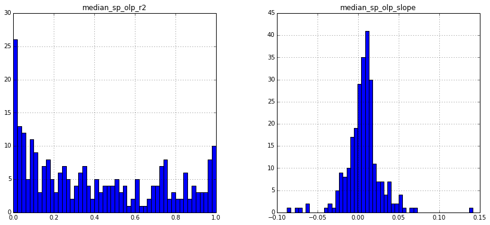

```python
lp, lp_adj = calculateSlope(by_subdivision, 'Median.SP.OLP')

lp[['median_sp_olp_r2', 'median_sp_olp_slope']].hist(bins=50, figsize=[14,6])
```

```python
print "The best fit:"
lp[lp.median_sp_olp_r2 == lp.median_sp_olp_r2.max()]
```

```
The best fit:
```

| Subdiv | median_sp_olp_slope | median_sp_olp_r2 | median_sp_olp_min | median_sp_olp_max | sales_count |
| --- | --- | --- | --- | --- | --- |
| Glen Berne Estates | 0.01725 | 0.998975 | 0.910364 | 0.944864 | 15 |

1 rows × 5 columns

```python
print "The Worst fit:"
lp[lp.median_sp_olp_r2 == lp.median_sp_olp_r2.min()]
```

```
The Worst fit:
```

| Subdiv | median_sp_olp_slope | median_sp_olp_r2 | median_sp_olp_min | median_sp_olp_max | sales_count |
| --- | --- | --- | --- | --- | --- |
| The Ests At St Annes | -0.000046 | 0.000002 | 0.899826 | 1.000702 | 41 |

1 rows × 5 columns

### The top and bottom 5 for sp/olp

```python
print "TOP 5:"
lp.sort(['median_sp_olp_slope'], ascending=False).head(5)
```

```
TOP 5:
```

| Subdiv | median_sp_olp_slope | median_sp_olp_r2 | median_sp_olp_min | median_sp_olp_max | sales_count |
| --- | --- | --- | --- | --- | --- |
| Wilmington - Brown-Burton Winchester Park Area (6.02) | 0.141411 | 0.840505 | 0.451005 | 0.906818 | 84 |
| Wilmington - Eastlawn Area (6.01) | 0.068332 | 0.730608 | 0.751880 | 0.984556 | 45 |
| Penn Acres South | 0.064288 | 0.763289 | 0.833333 | 0.961908 | 18 |
| Klair Estates | 0.057323 | 0.737885 | 0.776425 | 0.961645 | 27 |
| Linden Knoll | 0.053995 | 0.724997 | 0.817936 | 0.929530 | 28 |

5 rows × 5 columns

```python
print "TOP 5 (adjusted for better r-squared):"
lp_adj.sort(['median_sp_olp_slope'], ascending=False).head(5)
```

```
TOP 5 (adjusted for better r-squared):
```

| Subdiv | median_sp_olp_slope | median_sp_olp_r2 | median_sp_olp_min | median_sp_olp_max | sales_count |
| --- | --- | --- | --- | --- | --- |
| Wilmington - Brown-Burton Winchester Park Area (6.02) | 0.141411 | 0.840505 | 0.451005 | 0.906818 | 84 |
| Wilmington - Eastlawn Area (6.01) | 0.068332 | 0.730608 | 0.751880 | 0.984556 | 45 |
| Penn Acres South | 0.064288 | 0.763289 | 0.833333 | 0.961908 | 18 |
| Klair Estates | 0.057323 | 0.737885 | 0.776425 | 0.961645 | 27 |
| Linden Knoll | 0.053995 | 0.724997 | 0.817936 | 0.929530 | 28 |

5 rows × 5 columns

```python
print "BOTTOM 5:"
lp.sort(['median_sp_olp_slope']).head(5)
```

```
BOTTOM 5:
```

| Subdiv | median_sp_olp_slope | median_sp_olp_r2 | median_sp_olp_min | median_sp_olp_max | sales_count |
| --- | --- | --- | --- | --- | --- |
| Wilmington - Hill Top Area (22) | -0.087441 | 0.844109 | 0.677419 | 0.902478 | 64 |
| Lone Manor | -0.076225 | 0.967615 | 0.822002 | 0.974453 | 19 |
| Ninth Ward | -0.071521 | 0.611250 | 0.708333 | 0.968519 | 40 |
| Dunleith | -0.063999 | 0.963035 | 0.744709 | 0.939164 | 38 |
| Wilmington - Kirkwood Park Area (09) | -0.062686 | 0.253964 | 0.677215 | 1.000000 | 54 |

5 rows × 5 columns

```python
print "BOTTOM 5 (adjusted for better r-squared):"
lp_adj.sort(['median_sp_olp_slope']).head(5)
```

```
BOTTOM 5 (adjusted for better r-squared):
```

| Subdiv | median_sp_olp_slope | median_sp_olp_r2 | median_sp_olp_min | median_sp_olp_max | sales_count |
| --- | --- | --- | --- | --- | --- |
| Wilmington - Hill Top Area (22) | -0.087441 | 0.844109 | 0.677419 | 0.902478 | 64 |
| Lone Manor | -0.076225 | 0.967615 | 0.822002 | 0.974453 | 19 |
| Ninth Ward | -0.071521 | 0.611250 | 0.708333 | 0.968519 | 40 |
| Dunleith | -0.063999 | 0.963035 | 0.744709 | 0.939164 | 38 |
| Sedgely Farms | -0.038805 | 0.511784 | 0.901415 | 1.005867 | 18 |

5 rows × 5 columns

### Close look at the top and bottom subdivisions by sp/olp

#### Top subdivisions

```python
df[df.index == lp[lp.median_sp_olp_slope == lp.median_sp_olp_slope.max()].index]
```

| Subdiv | Year | Sales | Median Sold Price | Avg.SP | Median DOM | Avg.DOM | Median.SP.OLP | Median.SP.LP |
| --- | --- | --- | --- | --- | --- | --- | --- | --- |
| Wilmington - Brown-Burton Winchester Park Area (6.02) | 2010 | 18 | 10000 | 18870.83333 | 142.5 | 195.944444 | 0.451005 | 0.718832 |
| Wilmington - Brown-Burton Winchester Park Area (6.02) | 2011 | 16 | 14200 | 20628.12500 | 45.0 | 139.250000 | 0.773842 | 0.858859 |
| Wilmington - Brown-Burton Winchester Park Area (6.02) | 2012 | 18 | 12500 | 17966.66667 | 30.5 | 75.666667 | 0.820513 | 0.905705 |
| Wilmington - Brown-Burton Winchester Park Area (6.02) | 2013 | 32 | 17250 | 22828.59375 | 50.0 | 112.656250 | 0.906818 | 0.936173 |

4 rows × 8 columns

```python
df[df.index == lp[lp.median_sp_olp_slope == lp_adj.median_sp_olp_slope.max()].index]
```

| Subdiv | Year | Sales | Median Sold Price | Avg.SP | Median DOM | Avg.DOM | Median.SP.OLP | Median.SP.LP |
| --- | --- | --- | --- | --- | --- | --- | --- | --- |
| Wilmington - Brown-Burton Winchester Park Area (6.02) | 2010 | 18 | 10000 | 18870.83333 | 142.5 | 195.944444 | 0.451005 | 0.718832 |
| Wilmington - Brown-Burton Winchester Park Area (6.02) | 2011 | 16 | 14200 | 20628.12500 | 45.0 | 139.250000 | 0.773842 | 0.858859 |
| Wilmington - Brown-Burton Winchester Park Area (6.02) | 2012 | 18 | 12500 | 17966.66667 | 30.5 | 75.666667 | 0.820513 | 0.905705 |
| Wilmington - Brown-Burton Winchester Park Area (6.02) | 2013 | 32 | 17250 | 22828.59375 | 50.0 | 112.656250 | 0.906818 | 0.936173 |

4 rows × 8 columns

#### The bottom subdivisions

```python
df[df.index == lp[lp.median_sp_olp_slope == lp.median_sp_olp_slope.min()].index]
```

| Subdiv | Year | Sales | Median Sold Price | Avg.SP | Median DOM | Avg.DOM | Median.SP.OLP | Median.SP.LP |
| --- | --- | --- | --- | --- | --- | --- | --- | --- |
| Wilmington - Hill Top Area (22) | 2010 | 16 | 28750 | 48212.50000 | 44.5 | 129.000000 | 0.902478 | 0.930219 |
| Wilmington - Hill Top Area (22) | 2011 | 12 | 17000 | 21008.33333 | 28.5 | 72.500000 | 0.900389 | 0.905194 |
| Wilmington - Hill Top Area (22) | 2012 | 19 | 25000 | 35609.47368 | 109.0 | 140.526316 | 0.701155 | 0.945455 |
| Wilmington - Hill Top Area (22) | 2013 | 17 | 19900 | 23007.29412 | 96.0 | 112.058824 | 0.677419 | 0.757238 |

4 rows × 8 columns

### Throwing it all together for output to csv

```python
# Combine all of our stats into a single dataframe.
merge_out = pd.merge(
    left=median_dom[['sales_count','median_dom_slope', 'median_dom_r2', 'median_dom_min', 'median_dom_max']],
    right=median_saleprice[['median_sold_price_slope', 'median_sold_price_r2', 'median_sold_price_min', 'median_sold_price_max']],
    left_index=True,
    right_index=True)
merge_out = pd.merge(
    left=merge_out,
    right=lp[['median_sp_olp_slope', 'median_sp_olp_r2', 'median_sp_olp_min', 'median_sp_olp_max']],
    left_index=True,
    right_index=True)

# Add the rankings for each.
merge_out['dom_slope_rank'] = merge_out['median_dom_slope'].rank(ascending=True)
merge_out['median_price_rank'] = merge_out['median_sold_price_slope'].rank(ascending=False)
merge_out['sp_olp_rank'] = merge_out['median_sp_olp_slope'].rank(ascending=False)
merge_out['average_rank'] = merge_out[['dom_slope_rank', 'median_price_rank', 'sp_olp_rank']].mean(axis=1)
print "The Top Ten"
print merge_out.sort('average_rank')[['average_rank']].head(10)


merge_out.sort('average_rank').to_csv('data_out_ncco.txt', sep='\t')
```

```
The Top Ten
                                                       average_rank
Subdiv
Red Lion Chase                                             6.000000
Sherwood Park Ii                                          11.000000
Devon                                                     20.166667
Penn Acres South                                          21.000000
Brookmeade                                                30.500000
Surrey Park                                               30.666667
Wilmington - Brown-Burton Winchester Park Area (6.02)     32.000000
Dove Run                                                  35.000000
Westover Hills                                            38.000000
Colonial Heights                                          39.000000

[10 rows x 1 columns]
```

Click here to download the final data.